# Physically Feasible Dynamic Parameter Identification of the WAM Robot 7-DOF

*Research notebook from the paper:*

**Sousa, Cristóvão D. and Cortesão, Rui, "Physically feasible dynamic parameter identification of the 7-DOF WAM robot," Intelligent Robots and Systems (IROS), 2013 IEEE/RSJ International Conference on , pp.2868-2873, 3-7 Nov. 2013, Tokyo, Japan, doi: 10.1109/IROS.2013.6696762**

## Authors

- Cristóvão D. Sousa, crisjss@gmail.com
- Rui Cortesão, cortesao@isr.uc.pt

## Research Notebook

The research is done in [Python](http://www.python.org/) within an [IPython notebook](http://ipython.org/notebook.html) (the *Paper IROS2013 - Phys Feas Dyn Param Ident 7-DOF WAM Rob.ipynb* file). Data is in *data* folder. Additional Python support code is in *support_funcs* folder

The file *Paper IROS2013 - Phys Feas Dyn Param Ident 7-DOF WAM Rob.html* is a **preview** of the notebook. **It can be seen online at:**

**[Paper IROS2013 - Phys Feas Dyn Param Ident 7-DOF WAM Rob](http://goo.gl/8Xv6Mj)**

## Presentation

The slides and movies presented at IROS 2013 are avalable online [here](http://goo.gl/U9YmE5).

## Paper Correction

The published paper presents a physically feasible base parameter solution ("beta star", rightmost column of Table I) which was obtained not taking the friction parameter positiveness constraints into account, contrary to what is shown in equation (17). In this notebook, both the paper solution (without positiveness constraints on friction parameters) and the correct solution (with positiveness constraints on friction parameters) are computed and presented (to distinguish, variable names are suffixed with the words "paper" and "correct", respectivelly). Nevertheless, the differences between both solutions (with exception to the corrected friction parameter) are very small, arround 1%.

## How to run the code

- clone the git repository (it contains code and data) from https://github.com/cdsousa/IROS2013-Feas-Ident-WAM7
- open the *Paper IROS2013 - Phys Feas Dyn Param Ident 7-DOF WAM Rob.ipynb* notebook with [IPython](http://ipython.org/)
- edit and run the code

Dependencies:

- [Python](http://www.python.org/)
- [IPython](http://ipython.org/)
- [SymPy](http://sympy.org/)
- [Numpy](http://www.numpy.org/)
- [SciPy](http://www.scipy.org/)
- SymPyBotics (developed by the author Cristóvão D. Sousa)
- PyLMI-SDP (developed by the author Cristóvão D. Sousa)

## Questions & Feedback

Although being open source, the code can lack some better documentation. Feel free to contact the authors at crisjss@gmail.com We are open to help you to deploy this code or even your own implementation of the proposed algorithms.

## License

Copyright (c) 2013, Cristóvão Duarte Sousa, Rui Cortesão

All rights reserved.

This work is licensed under a [Creative Commons Attribution-NonCommercial-ShareAlike 4.0 International License](http://creativecommons.org/licenses/by-nc-sa/4.0/)

# Initializations

```python
datafolder = 'data/'
tmpfolder = 'tmp/'
```

```python
from sympy import init_printing
init_printing()

%pylab inline
```

# 1 - Robot Model

```python
import sympybotics
```

#### Robot Definition

```python
rbtdef = sympybotics.RobotDef("WAM Arm 7 DOF",
            [("-pi/2", 0, 0, "q"),
             ("pi/2", 0, 0, "q"),
             ("-pi/2", 0.045, 0.55, "q"),
             ("pi/2", -0.045, 0, "q"),
             ("-pi/2", 0, 0.3, "q"),
             ("pi/2", 0, 0, "q"),
             (0, 0, 0.06, "q")],
            dh_convention="standard")

rbtdef.frictionmodel = {'Coulomb', 'viscous'}
```

#### Model Generation

```python
%time rbt = sympybotics.RobotDynCode(rbtdef)
%time rbt.calc_base_parms()
```

```
CPU times: user 31.5 s, sys: 223 ms, total: 31.7 s
Wall time: 31.6 s
CPU times: user 24.5 s, sys: 180 ms, total: 24.7 s
Wall time: 24.9 s
```

```python
import pickle
with open(tmpfolder + 'robotmodels/wam7_model.pkl', 'wb') as file:
    pickle.dump( rbt, file )
```

## Base Dynamic Parameters

```python
import pickle
with open(tmpfolder +  'robotmodels/wam7_model.pkl', 'rb' ) as file:
          rbt = pickle.load( file )
```

```python
rbt.dyn.n_dynparms, rbt.dyn.n_base
```

$$\begin{pmatrix}84, & 57\end{pmatrix}$$

```python
rbt.dyn.baseparms.n()
```

$$\left[\begin{smallmatrix}{}L_{1yy} + L_{2zz}\\fv_{1}\\fc_{1}\\L_{2xx} - L_{2zz} + L_{3zz} - 1.1 l_{3y} + 0.300475 m_{3} + 0.300475 m_{4} + 0.300475 m_{5} + 0.300475 m_{6} + 0.300475 m_{7}\\L_{2xy}\\L_{2xz}\\L_{2yy} + L_{3zz} - 1.1 l_{3y} + 0.300475 m_{3} + 0.300475 m_{4} + 0.300475 m_{5} + 0.300475 m_{6} + 0.300475 m_{7}\\L_{2yz}\\l_{2x}\\l_{2z} - l_{3y} + 0.55 m_{3} + 0.55 m_{4} + 0.55 m_{5} + 0.55 m_{6} + 0.55 m_{7}\\fv_{2}\\fc_{2}\\L_{3xx} - L_{3zz} + L_{4zz} + 0.002025 m_{3}\\L_{3xy} - 0.045 l_{3y}\\L_{3xz}\\L_{3yy} + L_{4zz} - 0.002025 m_{3} - 0.00405 m_{4} - 0.00405 m_{5} - 0.00405 m_{6} - 0.00405 m_{7}\\L_{3yz}\\l_{3x} + 0.045 m_{3} + 0.045 m_{4} + 0.045 m_{5} + 0.045 m_{6} + 0.045 m_{7}\\l_{3z} + l_{4y}\\fv_{3}\\fc_{3}\\L_{4xx} - L_{4zz} + L_{5zz} - 0.6 l_{5y} + 0.002025 m_{4} + 0.092025 m_{5} + 0.092025 m_{6} + 0.092025 m_{7}\\L_{4xy} + 0.045 l_{4y}\\L_{4xz}\\L_{4yy} + L_{5zz} - 0.6 l_{5y} - 0.002025 m_{4} + 0.087975 m_{5} + 0.087975 m_{6} + 0.087975 m_{7}\\L_{4yz}\\l_{4x} - 0.045 m_{4} - 0.045 m_{5} - 0.045 m_{6} - 0.045 m_{7}\\l_{4z} - l_{5y} + 0.3 m_{5} + 0.3 m_{6} + 0.3 m_{7}\\fv_{4}\\fc_{4}\\L_{5xx} - L_{5zz} + L_{6zz}\\L_{5xy}\\L_{5xz}\\L_{5yy} + L_{6zz}\\L_{5yz}\\l_{5x}\\l_{5z} + l_{6y}\\fv_{5}\\fc_{5}\\L_{6xx} - L_{6zz} + L_{7yy} + 0.12 l_{7z} + 0.0036 m_{7}\\L_{6xy}\\L_{6xz}\\L_{6yy} + L_{7yy} + 0.12 l_{7z} + 0.0036 m_{7}\\L_{6yz}\\l_{6x}\\l_{6z} + l_{7z} + 0.06 m_{7}\\fv_{6}\\fc_{6}\\L_{7xx} - L_{7yy}\\L_{7xy}\\L_{7xz}\\L_{7yz}\\L_{7zz}\\l_{7x}\\l_{7y}\\fv_{7}\\fc_{7}\end{smallmatrix}\right]$$

# 2 - Trajectories and Recorded Data

```python
import pickle
import sympybotics
import numpy
```

```python
with open(tmpfolder +  'robotmodels/wam7_model.pkl', 'rb' ) as file:
          rbt = pickle.load( file )
```

### Plots

```python
with open(datafolder +  'trajectories/traj_shwfl_abq0.pkl', 'rb' ) as file:
          s_h_wf_l, a_b_q0 = pickle.load(file)
```

```python
h = 0.001
decimate = 10
h_plot = h*decimate

with open(datafolder +  'trajectories/traj.dat', 'r' ) as file:
          q_ref_orig = numpy.loadtxt(file)
s = q_ref_orig.shape[0] / decimate

q_ref = numpy.zeros((s, rbt.dof))
for i in range(s):
    q_ref[i, :] = q_ref_orig[i*decimate, :]
```

```python
si = 1/h_plot
sf = si + 20/h_plot
t = numpy.arange(sf-si) * h_plot
```

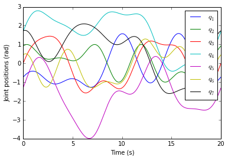

```python
from matplotlib import pyplot as plt
plt.close()

for i in range(rbt.dof):
    plt.plot(t,q_ref[si:sf,i], label="$q_%d$"%(i+1))
plt.legend()

plt.xlabel("Time (s)")
plt.ylabel("Joint positions (rad)")

plt.show()
```

# 3 - Regression Data Processing

```python
import os
import pickle
import math
import sympy
import numpy
import sympybotics
```

```python
with open(tmpfolder +  'robotmodels/wam7_model.pkl', 'rb' ) as file:
          rbt = pickle.load( file )
```

### Data Load

```python
from support_funcs.regr_data_proc import read_data
t_raw, q_raw, tau_raw, t_ref, q_ref = read_data( rbt.dof, 0.001,
                                                datafolder + 'recdata/rbtlog.dat',
                                                datafolder + 'trajectories/traj.dat')
```

### Some Plots

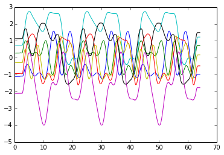

```python
from matplotlib import pyplot as plt
plt.close()

for i in range(q_raw.shape[1]):
    plt.plot(t_raw,q_raw[:,i])

plt.show()
```

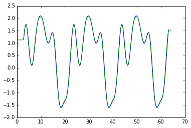

```python
from matplotlib import pyplot as plt
plt.close()

joint = 7
plt.plot(t_ref+2.6,q_ref[:,joint-1])
plt.plot(t_raw,q_raw[:,joint-1])

plt.show()
```

```python
del t_raw, q_raw, tau_raw, t_ref, q_ref
```

### Parameter Load

```python
with open(datafolder +  'trajectories/traj_shwfl_abq0.pkl', 'rb' ) as file:
          s_h_wf_l, a_b_q0 = pickle.load(file)

print(dict(zip(('S', 'h', 'wf', 'L'), s_h_wf_l)))
print('\n')
```

```
{'h': 0.040000000000000001, 'S': 500.0, 'L': 5.0, 'wf': 0.31415926535897931}
```

### Filter Cut-off Frequency Definition

```python
fc_mult = 10
```

```python
wf = float(s_h_wf_l[2])
L = float(s_h_wf_l[3])
fc = fc_mult * ( wf / (2*math.pi) * L )
fc
```

$$2.5$$

```python
fc_q = fc
fc_dq = fc
fc_ddq = fc

fc_tau = fc

si = int(3/0.001)
sf = -int(1/0.001)-172
```

### Data Filtering, Differentiation and Regression Data Generation

```python
rec_h = 0.001 # sampling time
```

```python
from support_funcs.regr_data_proc import read_data, diff_and_filt_data, gen_regr_matrices
from support_funcs.utils import _fprint

t_raw, q_raw, tau_raw, t_ref, q_ref = read_data(dof=rbt.dof, h=rec_h,
                                                rbtlogfile=datafolder + 'recdata/rbtlog.dat',
                                                trajreffile=datafolder + 'trajectories/traj.dat')

q, dq, ddq, tau = diff_and_filt_data(dof=rbt.dof, h=rec_h,  q_raw=q_raw, tau_raw=tau_raw,
                               fc_q=fc_q, fc_dq=fc_dq, fc_ddq=fc_ddq, fc_tau=fc_tau)

t_raw = t_raw[si:sf]; q_raw = q_raw[si:sf]; tau_raw = tau_raw[si:sf]
q = q[si:sf]; dq = dq[si:sf]; ddq = ddq[si:sf]; tau = tau[si:sf]

t_raw = t_raw - t_raw[0]

t = numpy.array(range(q.shape[0])) * rec_h

W, omega, Q1, R1, rho1 = gen_regr_matrices(rbt, q, dq, ddq, tau)




_fprint(' (cond=%f)'%numpy.linalg.cond(W))

_fprint('save')

%time \
numpy.savez_compressed(tmpfolder + 'procdata/raw', t=t_raw, q=q_raw, tau=tau_raw);\
numpy.savez_compressed(tmpfolder + 'procdata/proc', t=t, q=q, dq=dq, ddq=ddq, tau=tau); \
numpy.savez_compressed(tmpfolder + 'procdata/regr', W=W, omega=omega, Q1=Q1, R1=R1, rho1=rho1)

del t_raw, q_raw, tau_raw, t, q, dq, ddq, tau, W, omega, Q1, R1, rho1
```

```
 (cond=47.665784)
save
CPU times: user 15.3 s, sys: 1.02 s, total: 16.3 s
Wall time: 23.3 s
```

### Plot

```python
raw = numpy.load(tmpfolder + 'procdata/raw.npz')
tau_raw = raw['tau']
q_raw = raw['q']
del raw
proc = numpy.load(tmpfolder + 'procdata/proc.npz')
t = proc['t']
tau = proc['tau']
q = proc['q']
dq = proc['dq']
del proc
```

```python
q.shape
```

$$\begin{pmatrix}60000, & 7\end{pmatrix}$$

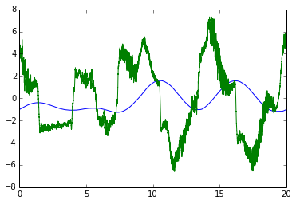

```python
from matplotlib import pyplot as plt
plt.close()

joint = 1
firsts = 20000
plt.plot(t[:firsts],q_raw[:,joint-1][:firsts])
#plt.plot(t[:firsts],q[:,joint-1][:firsts])
#plt.plot(t[:firsts],dq[:,joint-1][:firsts])
plt.plot(t[:firsts],tau_raw[:,joint-1][:firsts])

plt.show()
```

```python
del t, q, dq, tau, q_raw, tau_raw
```

# 4 - Near-zero Velocity Data Elimination

```python
import numpy
```

```python
proc = numpy.load(tmpfolder + 'procdata/proc.npz')
dq = proc['dq']
regr = numpy.load(tmpfolder + 'procdata/regr.npz')
omega = numpy.matrix(regr['omega'])
W = numpy.matrix(regr['W'])
del proc, regr
```

```python
w = omega
v = dq.flatten()
s = len(v)
```

```python
def selected_regression( obs_mat, output_vec, select_list=None ):

    if select_list is None:
        A = obs_mat[:,:]
        b = output_vec[:,:]
    else:
        A = obs_mat[select_list,:]
        b = output_vec[select_list,:]

    num = len(b)
    q1,r1 = numpy.linalg.qr(A)
    b1 = q1.T*b
    cond = numpy.linalg.cond(r1)
    x = numpy.linalg.inv(r1.T * r1) * r1.T * b1
    se = b - A*x
    err = numpy.linalg.norm(se)
    relerr = err / numpy.linalg.norm(b)
    mse = err**2/(num-A.shape[1])

    return x,se,{'num':num,'cond':cond,'mse':mse, 'relerr':relerr}
```

```python
list_v_threshold = numpy.arange(0.0, 0.02, 0.002).tolist() + numpy.arange(0.02, 0.08+1e-10, 0.02).tolist()
```

```python
selections = []
list_props = []
v_db_unc_regr = []
v_num = []
v_cond = []
v_relerr = []
v_mse = []
for idx, v_threshold in enumerate(list_v_threshold):
    r_vel = []
    if True:
        for i,vi in enumerate(v):
            if numpy.abs(vi) >= v_threshold:
                r_vel.append( i )
    else:
        for i in range(len(v)/rbt.dof):
            elimin = False
            for l in range(rbt.dof):
                vi = v[i*rbt.dof+l]
                if numpy.abs(vi) < v_threshold:
                    elimin = True
            if not elimin:
                r_vel += [i*rbt.dof+l for l in range(rbt.dof)]
    selections.append(r_vel)
    db_unc_regr_vel,se,props = selected_regression( W, w, r_vel )
    list_props.append(props)
    v_db_unc_regr.append(db_unc_regr_vel)
    v_num.append(props['num'])
    v_cond.append(props['cond'])
    v_relerr.append(props['relerr'])
    v_mse.append(props['mse'])

    print "%d %.3f %s"%(idx, v_threshold, props)
```

```
0 0.000 {'relerr': 0.065001185750151097, 'mse': 0.1919519060505985, 'num': 420000, 'cond': 47.665784291044233}
1 0.002 {'relerr': 0.060541569314894766, 'mse': 0.16888220553048766, 'num': 412627, 'cond': 47.665556047994585}
2 0.004 {'relerr': 0.058376032296917145, 'mse': 0.15840923418100106, 'num': 407455, 'cond': 48.016029495365316}
3 0.006 {'relerr': 0.057037930540787693, 'mse': 0.15231873436148083, 'num': 403143, 'cond': 48.151307558365183}
4 0.008 {'relerr': 0.056503807646075412, 'mse': 0.15017782241450842, 'num': 399946, 'cond': 48.282315104825493}
5 0.010 {'relerr': 0.056165780143189861, 'mse': 0.14894663698897942, 'num': 397333, 'cond': 48.3946416206919}
6 0.012 {'relerr': 0.055962844771432867, 'mse': 0.14830666199855119, 'num': 395123, 'cond': 48.517618144393552}
7 0.014 {'relerr': 0.055798139062068507, 'mse': 0.1478060402255989, 'num': 393086, 'cond': 48.638205359933131}
8 0.016 {'relerr': 0.055632994395873152, 'mse': 0.14724670987205066, 'num': 391077, 'cond': 48.76514081953475}
9 0.018 {'relerr': 0.055537544791336789, 'mse': 0.14707341213600827, 'num': 389130, 'cond': 48.89150137276274}
10 0.020 {'relerr': 0.055461842440442236, 'mse': 0.14699404582759037, 'num': 387294, 'cond': 49.020702056156416}
11 0.040 {'relerr': 0.055083634995312637, 'mse': 0.14699394960383888, 'num': 372967, 'cond': 51.06448480406862}
12 0.060 {'relerr': 0.05481760216003656, 'mse': 0.14661501527769974, 'num': 362076, 'cond': 53.381795030501316}
13 0.080 {'relerr': 0.054450672701337931, 'mse': 0.14498479649139431, 'num': 353395, 'cond': 54.590336383529625}
```

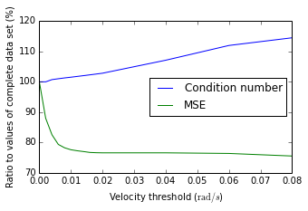

```python
from matplotlib import pyplot as plt

plt.figure(figsize=(5,3))
plt.plot(list_v_threshold,v_cond/v_cond[0]*100, label='Condition number')
plt.plot(list_v_threshold,v_mse/v_mse[0]*100, label='MSE')
#plt.plot(list_v_threshold,v_relerr/v_relerr[0]*100, label='rel err')
plt.legend(loc='right')
plt.axis([0.0,0.08,70,120])
plt.ylabel('Ratio to values of complete data set (%)')
plt.xlabel('Velocity threshold ($\mathrm{rad}/s$)')

plt.show()
```

```python
threshold_idx = 5
```

```python
(v_cond[threshold_idx] / v_cond[0]  - 1) * 100.0
```

$$1.52909962668$$

```python
(v_mse[threshold_idx]/v_mse[0] - 1) *100
```

$$-22.4041896465$$

```python
v_cond[threshold_idx]
```

$$48.3946416207$$

```python
select = selections[threshold_idx]
threshold = list_v_threshold[threshold_idx]

W_n0v = W[select,:]
omega_n0v = omega[select,:]

Q1_n0v,R1_n0v = numpy.linalg.qr(W_n0v)
rho1_n0v = Q1_n0v.T*omega_n0v
```

```python
%time \
numpy.savez_compressed(tmpfolder + 'procdata/regr_n0v', W=W_n0v, omega=omega_n0v, Q1=Q1_n0v, R1=R1_n0v, rho1=rho1_n0v)

del W, omega, W_n0v, omega_n0v, Q1_n0v, R1_n0v, rho1_n0v
```

```
CPU times: user 12.8 s, sys: 640 ms, total: 13.5 s
Wall time: 21 s
```